# Probability Functions and Number Generation

Hank Chen

27 10月 2019

# Probability Distribution Functions in R.

Every distribution that R handles has four functions. There is a root name, for example, the root name for the normal distribution is norm. This root is prefixed by one of the letters

- p for “probability”, the cumulative distribution function (c. d. f.)
- q for “quantile”, the inverse c. d. f.
- d for “density”, the density function (p. f. or p. d. f.)
- r for “random”, a random variable having the specified distribution

[output not shown]

## Random number generation

In class you have learned about different probability distributions. You can draw random numbers from existing distributions. It means that you can generate a set of random numbers that follow a specific distribution function. Using R as the root and the abreviation for the specific distribution you can generate the random numbers, see examples below.

## The Uniform Distribution

Were every value between a specified minimun and a maximun has an equal probability of ocurrence. the function in R that allows you to do that is `runif(n, min, max)`

```r
set.seed(123)
runif(1)
```

```
## [1] 0.2875775
```

```r
# Get a vector of 4 numbers
runif(4)
```

```
## [1] 0.7883051 0.4089769 0.8830174 0.9404673
```

```r
# Get a vector of 3 numbers from 0 to 100
runif(3, min=0, max=100)
```

```
## [1]  4.55565 52.81055 89.24190
```

```r
# Get 5 integers from 0 to 100
# Use max=101 because it will never actually equal 101
data1<-floor(runif(5, min=0, max=101))
# look at the object data in the enviroment
```

The sample function also generates random numbers.

```r
# This will do the same thing as the last code above, WITH replacement.
# sample(1:100, 10, replace=TRUE)

# To generate integers WITHOUT replacement:
# sample(1:100, 10, replace=FALSE)

# You can also create a sample out a data set.
# sample(data1, 10, replace=FALSE)
```

## The Normal distribution

To generate numbers from a normal distribution, use rnorm().

```r
# By default the mean is 0 and the standard deviation is 1.
set.seed(45)
rnorm(4)
```

```
## [1]  0.3407997 -0.7033403 -0.3795377 -0.7460474
```

```r
# Use a different mean and standard deviation
rnorm(4, mean=50, sd=10)
```

```
## [1] 41.01893 46.65206 44.98622 48.25464
```

# More graphs with ggplot

Two type of graphs allow you to show the distribution of a variable.

## Histogram and Bar graph

A histogram is bar graph that shows the frequency of occurence of each value.

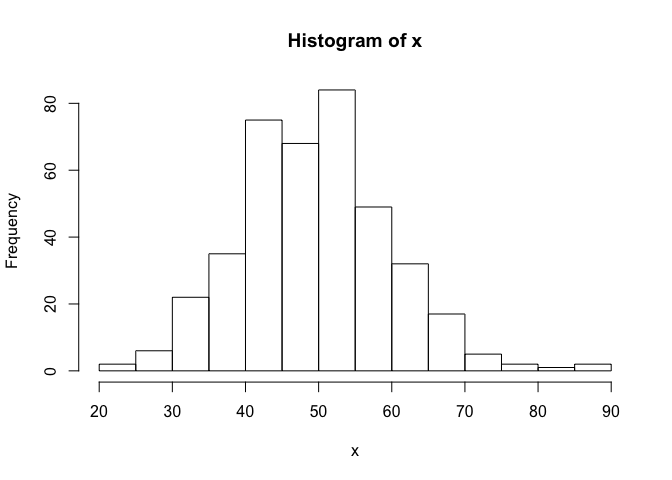

```r
# To check that the distribution looks right, make a histogram of the numbers
set.seed(45)
x <- rnorm(400, mean=50, sd=10)
# Using the basic R graphs hist() create a histogram
hist(x)
```

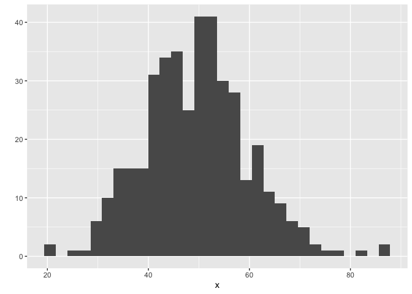

```r
# Using qplot
qplot(x, geom="histogram")
```

```r
y <- rnorm(400, mean=5, sd=0.5)

# To use ggplot you need your data in a data frame structure, that is the only way to feed data into ggplot.
dat<-data.frame(x,y)
```

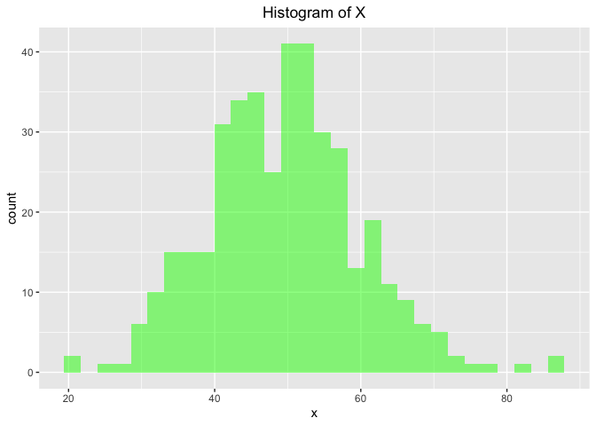

```r
# A bar graph in ggplot
ggplot(dat, aes(x))+
  geom_bar(stat='bin', fill="green", alpha=0.5)+
labs(title="Histogram of X")+ theme(plot.title = element_text(hjust = 0.5))
```

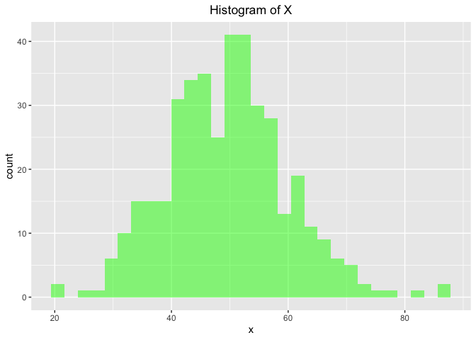

```r
# A histogram in ggplot
ggplot(dat, aes(x))+
  geom_histogram(fill="green", alpha=0.5)+
labs(title="Histogram of X")+ theme(plot.title = element_text(hjust = 0.5))
```

```r
#See they look the same
```

# Making a better histogram

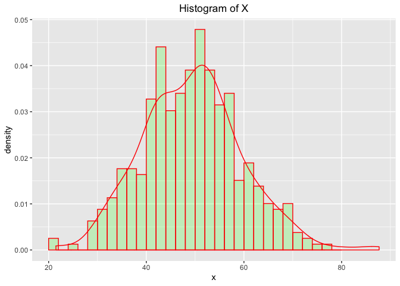

```r
# Once you create your graph you see a warning about the bins change that using breaks=seq()
# Here you also change the y axis to be the density instead of the frequency.
ggplot(dat, aes(x))+
geom_histogram(aes(y =..density..), fill="green", breaks=seq(20, 80, by = 2), col="red", alpha = .2)+ geom_density(col=2) +
labs(title="Histogram of X")+ theme(plot.title = element_text(hjust = 0.5))
```

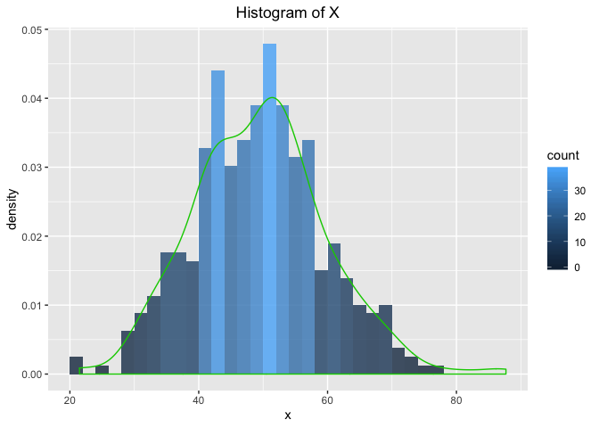

```r
#Now you want to change the attribute fill= so that it incorporates de information about the number (count) of observation in that range.
#Here you are also removing the atribute color from the geom_hist adding the geom_density() with the color attribute being equal to 3
ggplot(dat, aes(x))+
geom_histogram(aes(y =..density.., fill=..count..), breaks=seq(20, 80, by = 2), alpha = .8)+ geom_density(col=3) + labs(title="Histogram of X")+ theme(plot.title = element_text(hjust = 0.5))
```

# Boxplot

A boxplot is also a graph that provides a visualization about the distribution of your variable of vector

Below a boxplot for the avg_SAT in our college data.

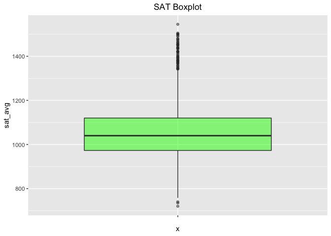

```r
college <- read.csv("http://672258.youcanlearnit.net/college.csv")

# Box plot
ggplot(data=college, aes(x="",  y=sat_avg))+
  geom_boxplot(fill="green", alpha=0.5)+
labs(title="SAT Boxplot") +
   theme(plot.title = element_text(hjust = 0.5))
```

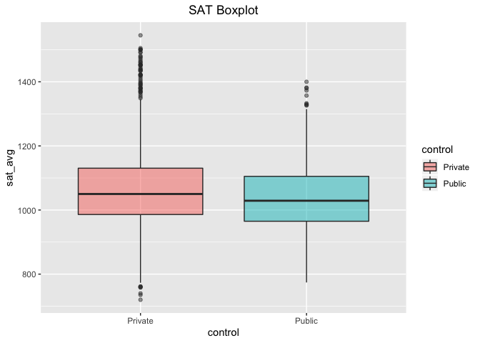

```r
# Boxplot that incorporates  separates the sat in public and private showing the distribution and also assigns the control variable to the atribute fill so each on has a different color.
ggplot(data=college, aes(x=control,  y=sat_avg, fill=control))+
  geom_boxplot( alpha=0.5)+
labs(title="SAT Boxplot") +
   theme(plot.title = element_text(hjust = 0.5))
```

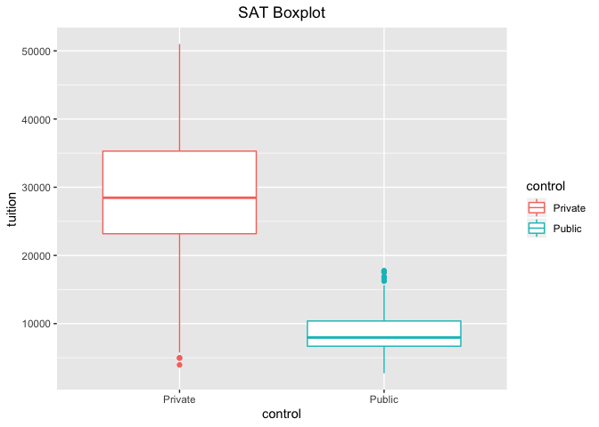

```r
ggplot(data=college, aes(x=control,  y=tuition, color=control))+
  geom_boxplot()+
labs(title="SAT Boxplot") +
   theme(plot.title = element_text(hjust = 0.5))
```

# Your turn Assingment 2

Play around with this functions, start by looking at the documentation in R. For example ?punif or ?qnorm ? sample

- Create a new Rmardown document
- Generate a vector y of 100 observations from the normal distribution with mean=3 and standart deviation sd=7
- Generate a vector z of 100 observations from the normal distribution with mean=7 and sd=3
- Generate a vector u of 100 observations from the uniform distribution
- Generate a vector v of 100 observations of integers between 0 to 500 without replacement
- Make a histogram of y and v
- Make a box plot of z
- Using the data from college make a boxplot of the average faculty salary separate by public and private universities

```r
set.seed(245)
```